# Bayesian GLM Part3

```r
## To get the slope on a scale that is based on a unit change in the
## predictor (rather than a unit change in scaled log-transformed
## area)
## Note, type= "response" is would be ignored
peake_brm4 |>
  emtrends(~1, var = "AREA")
```

```
 1       AREA.trend lower.HPD upper.HPD
 overall   0.000105  8.83e-05  0.000123

Point estimate displayed: median
HPD interval probability: 0.95
```

```r
## As if we had not scaled the predictor (but did log-transform it)
peake_brm4 |>
  emtrends(~0, var = "log(AREA)") |>
  tidy_draws() |>
  mutate(.value = exp(`1 overall`)) |>
  summarise_draws(median,
                  HDInterval::hdi)
```

```
# A tibble: 2 × 4
  variable  median lower upper
  <chr>      <dbl> <dbl> <dbl>
1 1 overall  0.819 0.690 0.963
2 .value     2.27  1.99  2.62
```

```r
## peake_brm4 |>
##   emmeans(~AREA, type = "response", at = list(AREA = c(1, 2))) |>
##   pairs(reverse = TRUE)

## peake_brm4 |>
##   emmeans(~AREA, type = "response", at = list(AREA = c(10, 20))) |>
##   pairs(reverse = TRUE)
```

**tidy_draws**

Return the draws (samples) for each parameter in wide format

```r
peake_brm4 |> tidy_draws()
```

```
# A tibble: 2,400 × 18
   .chain .iteration .draw b_Intercept b_scalelogAREA shape Intercept
    <int>      <int> <int>       <dbl>          <dbl> <dbl>     <dbl>
 1      1          1     1        5.71          1.03   3.90      5.71
 2      1          2     2        5.99          0.893  3.64      5.99
 3      1          3     3        5.55          0.993  7.19      5.55
 4      1          4     4        5.70          1.07   5.62      5.70
 5      1          5     5        5.82          0.930  8.80      5.82
 6      1          6     6        5.73          0.958  7.12      5.73
 7      1          7     7        5.70          1.17   7.88      5.70
 8      1          8     8        5.85          0.900  4.45      5.85
 9      1          9     9        5.70          0.888  4.21      5.70
10      1         10    10        5.65          0.966  7.02      5.65
# ℹ 2,390 more rows
# ℹ 11 more variables: prior_Intercept <dbl>, prior_b <dbl>, prior_shape <dbl>,
#   lprior <dbl>, lp__ <dbl>, accept_stat__ <dbl>, stepsize__ <dbl>,
#   treedepth__ <dbl>, n_leapfrog__ <dbl>, divergent__ <dbl>, energy__ <dbl>
```

```r
peake_brm4 |> get_variables()
```

```
 [1] "b_Intercept"     "b_scalelogAREA"  "shape"           "Intercept"
 [5] "prior_Intercept" "prior_b"         "prior_shape"     "lprior"
 [9] "lp__"            "accept_stat__"   "stepsize__"      "treedepth__"
[13] "n_leapfrog__"    "divergent__"     "energy__"
```

```r
peake_brm4$fit |>
    tidy_draws() |>
    dplyr::select(matches('^b_.*'))  |>
    exp() |>
    summarise_draws(median,
                    HDInterval::hdi,
                    rhat, length, ess_bulk, ess_tail)
```

```
# A tibble: 2 × 8
  variable       median  lower  upper  rhat length ess_bulk ess_tail
  <chr>           <dbl>  <dbl>  <dbl> <dbl>  <dbl>    <dbl>    <dbl>
1 b_Intercept    307.   256.   360.   1.000   2400    2284.    2362.
2 b_scalelogAREA   2.75   2.34   3.28 1.00    2400    2288.    2165.
```

The above can be useful for exploring the full posteriors of all the parameters of performing specific calculations using the posteriors, summarising the parameters takes a few more steps.

```r
peake_brm4 |>
    tidy_draws() |>
    exp() |>
    gather_variables() |>
    median_hdci()
```

```
# A tibble: 15 × 7
   .variable         .value   .lower   .upper .width .point .interval
   <chr>              <dbl>    <dbl>    <dbl>  <dbl> <chr>  <chr>
 1 accept_stat__   2.61e+ 0 2.07e+ 0 2.72e+ 0   0.95 median hdci
 2 b_Intercept     3.07e+ 2 2.56e+ 2 3.60e+ 2   0.95 median hdci
 3 b_scalelogAREA  2.75e+ 0 2.34e+ 0 3.28e+ 0   0.95 median hdci
 4 divergent__     1   e+ 0 1   e+ 0 1   e+ 0   0.95 median hdci
 5 energy__        6.00e+70 4.52e+69 2.79e+72   0.95 median hdci
 6 Intercept       3.07e+ 2 2.56e+ 2 3.60e+ 2   0.95 median hdci
 7 lp__            7.17e-71 1.47e-74 2.12e-70   0.95 median hdci
 8 lprior          1.15e- 4 5.54e- 5 2.13e- 4   0.95 median hdci
 9 n_leapfrog__    1.10e+ 3 2.01e+ 1 1.10e+ 3   0.95 median hdci
10 prior_b         9.94e- 1 3.30e- 2 6.22e+ 0   0.95 median hdci
11 prior_Intercept 4.06e+ 2 2.04e+ 1 2.66e+ 3   0.95 median hdci
12 prior_shape     1   e+ 0 1   e+ 0 1.41e+ 0   0.95 median hdci
13 shape           7.59e+ 2 5.39e+ 0 3.58e+ 4   0.95 median hdci
14 stepsize__      1.99e+ 0 1.98e+ 0 2.13e+ 0   0.95 median hdci
15 treedepth__     7.39e+ 0 7.39e+ 0 2.01e+ 1   0.95 median hdci
```

The `gather_draws` on the other hand, conveniently combines `tidy_draws` and `gather_variables` together in a single command. Furthermore, it returns all of the variables. The `spread_draws` function allows users to target specific variables (either by naming them in full or via regexp).

**gather_draws**

Due to the presence of a log transform in the predictor, it is better to use the regex version.

```r
peake_brm4 |> get_variables()
```

```
 [1] "b_Intercept"     "b_scalelogAREA"  "shape"           "Intercept"
 [5] "prior_Intercept" "prior_b"         "prior_shape"     "lprior"
 [9] "lp__"            "accept_stat__"   "stepsize__"      "treedepth__"
[13] "n_leapfrog__"    "divergent__"     "energy__"
```

```r
peake_draw <- peake_brm4 |> gather_draws(`b_.*`,  regex=TRUE)
peake_draw
```

```
# A tibble: 4,800 × 5
# Groups:   .variable [2]
   .chain .iteration .draw .variable   .value
    <int>      <int> <int> <chr>        <dbl>
 1      1          1     1 b_Intercept   5.71
 2      1          2     2 b_Intercept   5.99
 3      1          3     3 b_Intercept   5.55
 4      1          4     4 b_Intercept   5.70
 5      1          5     5 b_Intercept   5.82
 6      1          6     6 b_Intercept   5.73
 7      1          7     7 b_Intercept   5.70
 8      1          8     8 b_Intercept   5.85
 9      1          9     9 b_Intercept   5.70
10      1         10    10 b_Intercept   5.65
# ℹ 4,790 more rows
```

We can then summarise this

```r
peake_draw |> median_hdci()
```

```
# A tibble: 2 × 7
  .variable      .value .lower .upper .width .point .interval
  <chr>           <dbl>  <dbl>  <dbl>  <dbl> <chr>  <chr>
1 b_Intercept      5.73  5.56    5.90   0.95 median hdci
2 b_scalelogAREA   1.01  0.852   1.19   0.95 median hdci
```

```r
peake_brm4 |>
    gather_draws(`b_.*`,  regex=TRUE) |>
    mutate(.value = exp(.value)) |>
    summarise_draws(median,
                    HDInterval::hdi,
                    rhat, length, ess_bulk, ess_tail)
```

```
# A tibble: 2 × 9
# Groups:   .variable [2]
  .variable      variable median  lower  upper  rhat length ess_bulk ess_tail
  <chr>          <chr>     <dbl>  <dbl>  <dbl> <dbl>  <dbl>    <dbl>    <dbl>
1 b_Intercept    .value   307.   256.   360.   1.000   2400    2304.    2370.
2 b_scalelogAREA .value     2.75   2.34   3.28 1.01    2400    2324.    2225.
```

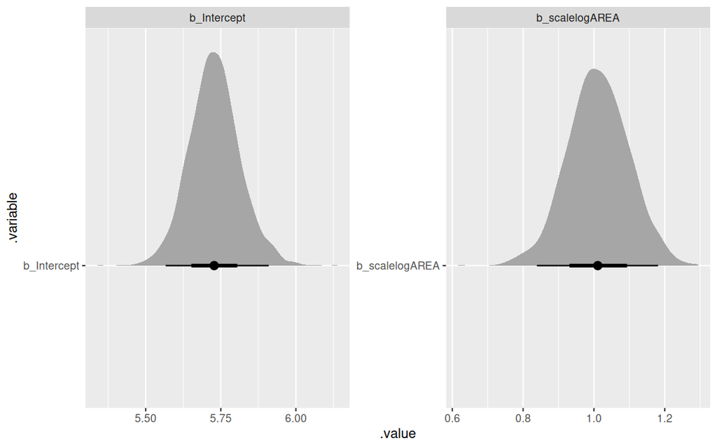

```r
peake_brm4 |>
  gather_draws(`b_.*`, regex=TRUE) |>
  ggplot() +
  stat_halfeye(aes(x=.value,  y=.variable)) +
  facet_wrap(~.variable, scales='free')
```

We could alternatively express the parameters on the response scale.

```r
peake_brm4 |>
  gather_draws(`.Intercept.*|.*AREA.*`, regex=TRUE) |>
  group_by(.variable) |>
  mutate(.value=exp(.value)) |>
  median_hdci()
```

[output not shown]

**Conclusions:**

**bayesplot**

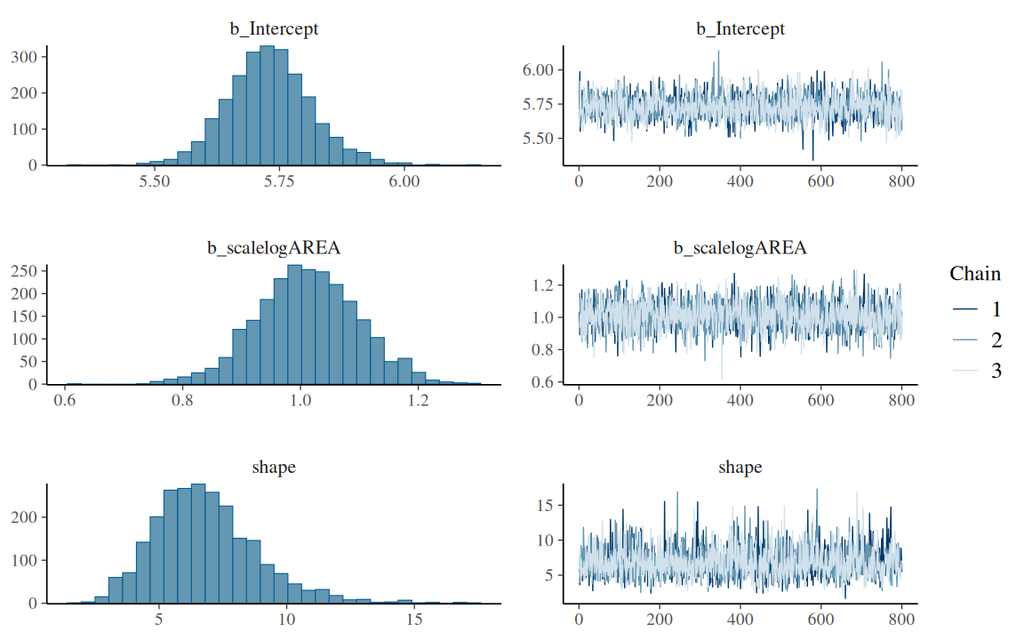

```r
peake_brm4 |> plot(plotfun='mcmc_intervals')
```

**spread_draws**

```r
peake_brm4 |> spread_draws(`b_.*`,  regex=TRUE)
```

```
# A tibble: 2,400 × 5
   .chain .iteration .draw b_Intercept b_scalelogAREA
    <int>      <int> <int>       <dbl>          <dbl>
 1      1          1     1        5.71          1.03
 2      1          2     2        5.99          0.893
 3      1          3     3        5.55          0.993
 4      1          4     4        5.70          1.07
 5      1          5     5        5.82          0.930
 6      1          6     6        5.73          0.958
 7      1          7     7        5.70          1.17
 8      1          8     8        5.85          0.900
 9      1          9     9        5.70          0.888
10      1         10    10        5.65          0.966
# ℹ 2,390 more rows
```

```r
## summarised
peake_brm4 |>
    as_draws_df() |>
    dplyr::select(starts_with("b_")) |>
    summarise_draws("median",
                    ~ HDInterval::hdi(.x),
                    "rhat",
                    "ess_bulk")
```

```
# A tibble: 2 × 6
  variable       median lower upper  rhat ess_bulk
  <chr>           <dbl> <dbl> <dbl> <dbl>    <dbl>
1 b_Intercept      5.73 5.56   5.90 1.000    2285.
2 b_scalelogAREA   1.01 0.852  1.19 1.00     2289.
```

```r
## summarised on fractional scale
peake_brm4 |>
    as_draws_df() |>
    dplyr::select(starts_with("b_")) |>
    mutate(across(everything(), exp)) |>
    summarise_draws("median",
                    ~ HDInterval::hdi(.x),
                    "rhat",
                    "ess_bulk")
```

```
# A tibble: 2 × 6
  variable       median  lower  upper  rhat ess_bulk
  <chr>           <dbl>  <dbl>  <dbl> <dbl>    <dbl>
1 b_Intercept    307.   256.   360.   1.000    2285.
2 b_scalelogAREA   2.75   2.34   3.28 1.00     2289.
```

**posterior_samples**

```r
peake_brm4 |> posterior_samples() |> as_tibble()
```

```
# A tibble: 2,400 × 9
   b_Intercept b_scalelogAREA shape Intercept prior_Intercept prior_b
         <dbl>          <dbl> <dbl>     <dbl>           <dbl>   <dbl>
 1        5.71          1.03   3.90      5.71            6.22  -0.224
 2        5.99          0.893  3.64      5.99            5.80  -0.311
 3        5.55          0.993  7.19      5.55            5.27  -0.809
 4        5.70          1.07   5.62      5.70            4.52   0.474
 5        5.82          0.930  8.80      5.82            5.26  -1.51
 6        5.73          0.958  7.12      5.73            6.43  -0.905
 7        5.70          1.17   7.88      5.70            6.38   0.516
 8        5.85          0.900  4.45      5.85            5.42  -1.20
 9        5.70          0.888  4.21      5.70            8.25  -0.625
10        5.65          0.966  7.02      5.65            6.61   1.76
# ℹ 2,390 more rows
# ℹ 3 more variables: prior_shape <dbl>, lprior <dbl>, lp__ <dbl>
```

**\(R^2\)**

```r
peake_brm4 |> bayes_R2(summary=FALSE) |> median_hdci()
```

```
          y      ymin      ymax .width .point .interval
1 0.7350019 0.6851285 0.7519736   0.95 median      hdci
```

**Modelsummary**

```r
peake_brm4 |> modelsummary(
  statistic = c("conf.low", "conf.high"),
  shape = term ~ statistic
)
```

|  | (1) Est. | (1) 2.5 % | (1) 97.5 % |
| --- | --- | --- | --- |
| b_Intercept | 5.728 | 5.566 | 5.909 |
| b_scalelogAREA | 1.011 | 0.839 | 1.181 |
| Num.Obs. | 25 |  |  |
| R2 | 0.735 |  |  |
| ELPD | -156.3 |  |  |
| ELPD s.e. | 5.8 |  |  |
| LOOIC | 312.6 |  |  |
| LOOIC s.e. | 11.6 |  |  |
| WAIC | 312.5 |  |  |
| RMSE | 248.73 |  |  |

```r
peake_brm4 |> modelsummary(
  statistic = c("conf.low", "conf.high"),
  shape = term ~ statistic,
  exponentiate = TRUE
)
```

|  | (1) Est. | (1) 2.5 % | (1) 97.5 % |
| --- | --- | --- | --- |
| b_Intercept | 307.330 | 261.511 | 368.489 |
| b_scalelogAREA | 2.748 | 2.314 | 3.258 |
| Num.Obs. | 25 |  |  |
| R2 | 0.735 |  |  |
| ELPD | -156.3 |  |  |
| ELPD s.e. | 5.8 |  |  |
| LOOIC | 312.6 |  |  |
| LOOIC s.e. | 11.6 |  |  |
| WAIC | 312.5 |  |  |
| RMSE | 247.50 |  |  |

```r
modelsummary(list("Raw" = peake_brm4, "Exponentiated" = peake_brm4),
  statistic = c("conf.low", "conf.high"),
  shape = term ~ statistic,
  exponentiate = c(FALSE, TRUE)
)
```

|  | Raw Est. | Raw 2.5 % | Raw 97.5 % | Exponentiated Est. | Exponentiated 2.5 % | Exponentiated 97.5 % |
| --- | --- | --- | --- | --- | --- | --- |
| b_Intercept | 5.728 | 5.566 | 5.909 | 307.330 | 261.511 | 368.489 |
| b_scalelogAREA | 1.011 | 0.839 | 1.181 | 2.748 | 2.314 | 3.258 |
| Num.Obs. | 25 |  |  | 25 |  |  |
| R2 | 0.735 |  |  | 0.735 |  |  |
| ELPD | -156.3 |  |  | -156.3 |  |  |
| ELPD s.e. | 5.8 |  |  | 5.8 |  |  |
| LOOIC | 312.6 |  |  | 312.6 |  |  |
| LOOIC s.e. | 11.6 |  |  | 11.6 |  |  |
| WAIC | 312.5 |  |  | 312.5 |  |  |
| RMSE | 248.38 |  |  | 247.83 |  |  |

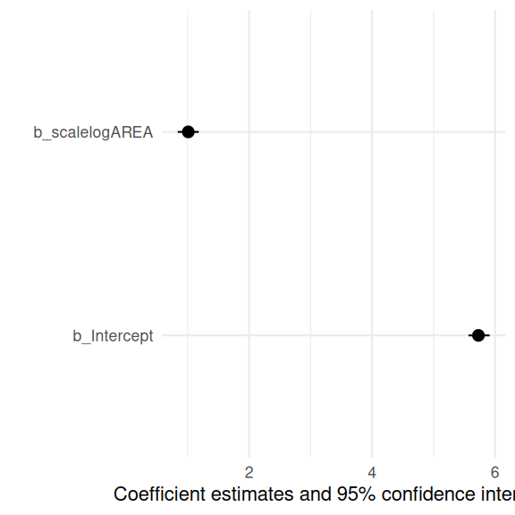

```r
peake_brm4 |> modelplot()
```

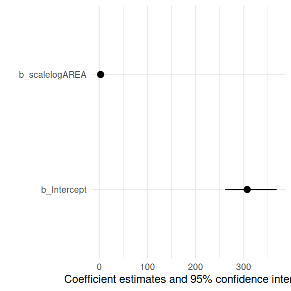

```r
peake_brm4 |> modelplot(exponentiate = TRUE)
```

# 11 Hypothesis testing

**rstanarm**

**Prob. of effect**

Unfortunately, the inline log-transformation of the predictor interfers with `hypothesis()`’s ability to find the slope. We can get around this by renaming before calling `hypothesis()`.

```r
peake_rstanarm4 |> as.data.frame() |> rename(lAREA=`log(AREA)`) |> hypothesis('lAREA>0')
```

```
Hypothesis Tests for class :
   Hypothesis Estimate Est.Error CI.Lower CI.Upper Evid.Ratio Post.Prob Star
1 (lAREA) > 0     0.82      0.09     0.68     0.96        Inf         1    *
---
'CI': 90%-CI for one-sided and 95%-CI for two-sided hypotheses.
'*': For one-sided hypotheses, the posterior probability exceeds 95%;
for two-sided hypotheses, the value tested against lies outside the 95%-CI.
Posterior probabilities of point hypotheses assume equal prior probabilities.
```

**Conclusions:**

- the probability of a positive effect of mussel clump area on number of individuals is 1. That is, there is, we are 100% confident that there is an effect.
- the evidence ratio is normally the ratio of the number of cases that satisty the hypothesis to the number of cases that do not. Since the number of cases that do not satisfy the hypothesis is 0, the evidence ratio is Inf (since division by 0)

Alternatively…

```r
peake_rstanarm4 |> tidy_draws() |> summarise(P=mean(`log(AREA)`>0))
```

```
# A tibble: 1 × 1
      P
  <dbl>
1     1
```

**Conclusions:**

- the probability of a positive effect of mussel clump area on number of individuals is 1. That is, there is, we are 100% confident that there is an effect.

**Change 5000 to 10000 (Method 1)**

```r
newdata = list(AREA=c(5000, 10000))
## fractional scale
peake_rstanarm4 |> emmeans(~AREA,  at=newdata, type = 'response') |> pairs(reverse = TRUE)
```

```
 contrast             ratio lower.HPD upper.HPD
 AREA10000 / AREA5000  1.77      1.55      1.98

Point estimate displayed: median
Results are back-transformed from the log scale
HPD interval probability: 0.95
```

```r
## absolute scale
peake_rstanarm4 |> emmeans(~AREA,  at=newdata) |> regrid() |> pairs(reverse = TRUE)
```

```
 contrast             estimate lower.HPD upper.HPD
 AREA10000 - AREA5000      270       188       378

Point estimate displayed: median
HPD interval probability: 0.95
```

**Conclusions:**

If we want to derive other properties, such as the percentage change, then we use `tidy_draws()` and then simple `tidyverse` spreadsheet operation.

```r
peake_mcmc <- peake_rstanarm4 |> emmeans(~AREA,  at=newdata) |>
    regrid() |>
    tidy_draws() |>
    rename_with(~str_replace(., 'AREA ', 'p')) |>
    mutate(Eff=p10000 - p5000,
           PEff=100*Eff/p5000)
peake_mcmc |> head()
```

```
# A tibble: 6 × 7
  .chain .iteration .draw p5000 p10000   Eff  PEff
   <int>      <int> <int> <dbl>  <dbl> <dbl> <dbl>
1      1          1     1  361.   630.  269.  74.5
2      1          2     2  327.   572.  245.  74.9
3      1          3     3  374.   601.  227.  60.7
4      1          4     4  372.   658.  286.  76.9
5      1          5     5  319.   576.  257.  80.4
6      1          6     6  353.   587.  234.  66.3
```

Now we can calculate the medians and HPD intervals of each column (and ignore the `.chain`, `.iteration` and `.draw`).

```r
peake_mcmc |> tidyMCMC(estimate.method='median',
                       conf.int=TRUE, conf.method='HPDinterval')
```

```
# A tibble: 7 × 5
  term       estimate std.error conf.low conf.high
  <chr>         <dbl>     <dbl>    <dbl>     <dbl>
1 .chain          2       0.817      1         3
2 .iteration    400.    231.         1       761
3 .draw        1200.    693.         1      2281
4 p5000         355.     34.4      287.      423.
5 p10000        629.     75.8      484.      777.
6 Eff           274.     49.3      188.      378.
7 PEff           77.1    10.7       54.9      97.5
```

Alternatively, we could use `median_hdci`

```r
peake_mcmc |> median_hdci(PEff)
```

```
# A tibble: 1 × 6
   PEff .lower .upper .width .point .interval
  <dbl>  <dbl>  <dbl>  <dbl> <chr>  <chr>
1  76.8   55.1   97.8   0.95 median hdci
```

**Conclusions:**

- the percentage change in expected number of individuals associated with an increase in mussel clump area from 5,000 to 10,000 is 76.81% with a 95% credibility interval of 55.07 97.81

To get the probability that the effect is greater than a 50% increase.

```r
peake_mcmc |> summarise(P=mean(PEff>50))
```

```
# A tibble: 1 × 1
      P
  <dbl>
1 0.994
```

**Conclusions:**

- the probability that the number of individuals will increase by more than 50% following an increase in mussel clump area from 5,000 to 10,000 is 0.99.

Finally, we could alternatively use `hypothesis()`. Note that when we do so, the estimate is the difference between the effect and the hypothesised effect (50%).

```r
peake_mcmc |> hypothesis('PEff>50')
```

```
Hypothesis Tests for class :
       Hypothesis Estimate Est.Error CI.Lower CI.Upper Evid.Ratio Post.Prob
1 (PEff)-(50) > 0    27.15     10.71     9.84    45.03        159      0.99
  Star
1    *
---
'CI': 90%-CI for one-sided and 95%-CI for two-sided hypotheses.
'*': For one-sided hypotheses, the posterior probability exceeds 95%;
for two-sided hypotheses, the value tested against lies outside the 95%-CI.
Posterior probabilities of point hypotheses assume equal prior probabilities.
```

**Change 5000 to 10000 (Method 2)**

```r
## Note, the P value is on absolute difference
newdata = list(AREA=c(5000, 10000))
peake_rstanarm4 |>
    emmeans(~AREA,  at=newdata) |>
    regrid() |>
    pairs(reverse = TRUE) |>
    tidy_draws() |>
    summarise(across(contains('contrast'),
                     list(P = ~ mean(.>50),
                          HDCI = ~ median_hdci(.)),
                     .names = c('{.fn}')
                     )) |>
    tidyr::unpack(HDCI)
```

```
# A tibble: 1 × 7
      P     y  ymin  ymax .width .point .interval
  <dbl> <dbl> <dbl> <dbl>  <dbl> <chr>  <chr>
1     1  270.  180.  370.   0.95 median hdci
```

We can also express this as a percentage change

```r
newdata = list(AREA=c(5000, 10000))
## Simple
peake_rstanarm4 |>
    emmeans(~AREA,  at=newdata) |>
    pairs(reverse = TRUE) |>
    regrid()
```

```
 contrast           ratio lower.HPD upper.HPD
 AREA10000/AREA5000  1.77      1.55      1.98

Point estimate displayed: median
HPD interval probability: 0.95
```

```r
## More advanced (both P and percent change)
peake_mcmc <- peake_rstanarm4 |>
    emmeans(~AREA,  at=newdata) |>
    pairs(reverse = TRUE) |>
    regrid() |>
    tidy_draws() |>
    mutate(across(contains('contrast'), ~ 100*(. - 1)))

peake_mcmc |>
    summarise(across(contains('contrast'),
                     list(P = ~ mean(.>50),
                          HDCI = ~ median_hdci(.)),
                     .names = c('{.fn}')
                     )) |>
    tidyr::unpack(HDCI)
```

```
# A tibble: 1 × 7
      P     y  ymin  ymax .width .point .interval
  <dbl> <dbl> <dbl> <dbl>  <dbl> <chr>  <chr>
1 0.994  76.8  55.1  97.8   0.95 median hdci
```

**Change 5000 to 10000 (Method 3)**

```r
peake_rstanarm4 |>
    linpred_draws(newdata = as.data.frame(newdata)) |>
    mutate(.linpred = exp(.linpred)) |>
    ungroup() |>
    group_by(.draw) |>
    summarise(Eff = diff(.linpred),
              PEff = 100*Eff/.linpred[1]) |>
    ungroup() |>
    mutate(P = mean(PEff>50)) |>
    pivot_longer(cols = -.draw) |>
    group_by(name) |>
    median_hdci()
```

```
# A tibble: 3 × 7
  name    value  .lower  .upper .width .point .interval
  <chr>   <dbl>   <dbl>   <dbl>  <dbl> <chr>  <chr>
1 Eff   270.    180.    370.      0.95 median hdci
2 P       0.994   0.994   0.994   0.95 median hdci
3 PEff   76.8    55.1    97.8     0.95 median hdci
```

```r
##OR
peake_rstanarm4 |>
    epred_draws(newdata = as.data.frame(newdata)) |>
    ungroup() |>
    group_by(.draw) |>
    summarise(Eff = diff(.epred),
              PEff = 100*Eff/.epred[1]) |>
    ungroup() |>
    mutate(P = mean(PEff>50)) |>
    pivot_longer(cols = -.draw) |>
    group_by(name) |>
    median_hdci()
```

```
# A tibble: 3 × 7
  name    value  .lower  .upper .width .point .interval
  <chr>   <dbl>   <dbl>   <dbl>  <dbl> <chr>  <chr>
1 Eff   270.    180.    370.      0.95 median hdci
2 P       0.994   0.994   0.994   0.95 median hdci
3 PEff   76.8    55.1    97.8     0.95 median hdci
```

```r
##OR for prediction of individual values
peake_rstanarm4 |>
    predicted_draws(newdata = as.data.frame(newdata)) |>
    ungroup() |>
    group_by(.draw) |>
    summarise(Eff = diff(.prediction),
              PEff = 100*Eff/.prediction[1]) |>
    ungroup() |>
    mutate(P = mean(PEff>50)) |>
    pivot_longer(cols = -.draw) |>
    group_by(name) |>
    median_hdci()
```

```
# A tibble: 3 × 7
  name    value   .lower   .upper .width .point .interval
  <chr>   <dbl>    <dbl>    <dbl>  <dbl> <chr>  <chr>
1 Eff   228.    -328.    1049       0.95 median hdci
2 P       0.578    0.578    0.578   0.95 median hdci
3 PEff   73.7    -85.3    528.      0.95 median hdci
```

**brm**

**Prob. of effect**

```r
peake_brm4 |> hypothesis('scalelogAREA>0')
```

```
Hypothesis Tests for class b:
          Hypothesis Estimate Est.Error CI.Lower CI.Upper Evid.Ratio Post.Prob
1 (scalelogAREA) > 0     1.01      0.09     0.87     1.15        Inf         1
  Star
1    *
---
'CI': 90%-CI for one-sided and 95%-CI for two-sided hypotheses.
'*': For one-sided hypotheses, the posterior probability exceeds 95%;
for two-sided hypotheses, the value tested against lies outside the 95%-CI.
Posterior probabilities of point hypotheses assume equal prior probabilities.
```

**Conclusions:**

- the probability of a positive effect of mussel clump area on number of individuals is 1. That is, there is, we are 100% confident that there is an effect.
- the evidence ratio is normally the ratio of the number of cases that satisty the hypothesis to the number of cases that do not. Since the number of cases that do not satisfy the hypothesis is 0, the evidence ratio is Inf (since division by 0)

Alternatively…

```r
peake_brm4 |> tidy_draws() |> summarise(P=mean(b_scalelogAREA>0))
```

```
# A tibble: 1 × 1
      P
  <dbl>
1     1
```

**Conclusions:**

- the probability of a positive effect of mussel clump area on number of individuals is 1. That is, there is, we are 100% confident that there is an effect.

**Change 5000 to 10000 (Method 1)**

```r
newdata = list(AREA=c(5000, 10000))
## fractional scale
peake_brm4 |> emmeans(~AREA,  at=newdata, type = 'response') |> pairs(reverse = TRUE)
```

```
 contrast             ratio lower.HPD upper.HPD
 AREA10000 / AREA5000  1.76      1.61      1.95

Point estimate displayed: median
Results are back-transformed from the log scale
HPD interval probability: 0.95
```

```r
## absolute scale
peake_brm4 |> emmeans(~AREA,  at=newdata) |> regrid() |> pairs(reverse = TRUE)
```

```
 contrast             estimate lower.HPD upper.HPD
 AREA10000 - AREA5000      269       193       351

Point estimate displayed: median
HPD interval probability: 0.95
```

**Conclusions:**

If we want to derive other properties, such as the percentage change, then we use `tidy_draws()` and then simple `tidyverse` spreadsheet operation.

```r
peake_mcmc <- peake_brm4 |> emmeans(~AREA,  at=newdata) |>
    regrid() |>
    tidy_draws() |>
    rename_with(~str_replace(., 'AREA ', 'p')) |>
    mutate(Eff=p10000 - p5000,
           PEff=100*Eff/p5000)
peake_mcmc |> head()
```

```
# A tibble: 6 × 7
  .chain .iteration .draw p5000 p10000   Eff  PEff
   <int>      <int> <int> <dbl>  <dbl> <dbl> <dbl>
1      1          1     1  346.   618.  272.  78.5
2      1          2     2  448.   740.  292.  65.1
3      1          3     3  294.   513.  219.  74.6
4      1          4     4  343.   624.  281.  82.0
5      1          5     5  381.   643.  262.  68.6
6      1          6     6  351.   601.  250.  71.3
```

Now we can calculate the medians and HPD intervals of each column (and ignore the `.chain`, `.iteration` and `.draw`).

```r
peake_mcmc |> tidyMCMC(estimate.method='median',
                       conf.int=TRUE, conf.method='HPDinterval')
```

```
# A tibble: 7 × 5
  term       estimate std.error conf.low conf.high
  <chr>         <dbl>     <dbl>    <dbl>     <dbl>
1 .chain          2       0.817      1         3
2 .iteration    400.    231.         1       761
3 .draw        1200.    693.         1      2281
4 p5000         353.     30.4      290.      412.
5 p10000        624.     64.6      506.      761.
6 Eff           271.     40.4      193.      351.
7 PEff           76.7     8.57      61.3      95.0
```

Alternatively, we could use `median_hdci`

```r
peake_mcmc |> median_hdci(PEff)
```

```
# A tibble: 1 × 6
   PEff .lower .upper .width .point .interval
  <dbl>  <dbl>  <dbl>  <dbl> <chr>  <chr>
1  76.4   61.3   95.0   0.95 median hdci
```

**Conclusions:**

- the percentage change in expected number of individuals associated with an increase in mussel clump area from 5,000 to 10,000 is 76.4% with a 95% credibility interval of 61.33 94.96

To get the probability that the effect is greater than a 50% increase.

```r
peake_mcmc |> summarise(P=mean(PEff>50))
```

```
# A tibble: 1 × 1
      P
  <dbl>
1 1.000
```

**Conclusions:**

Finally, we could alternatively use `hypothesis()`. Note that when we do so, the estimate is the difference between the effect and the hypothesised effect (50%).

```r
peake_mcmc |> hypothesis('PEff>50')
```

```
Hypothesis Tests for class :
       Hypothesis Estimate Est.Error CI.Lower CI.Upper Evid.Ratio Post.Prob
1 (PEff)-(50) > 0    26.69      8.57    13.15    41.07       2399         1
  Star
1    *
---
'CI': 90%-CI for one-sided and 95%-CI for two-sided hypotheses.
'*': For one-sided hypotheses, the posterior probability exceeds 95%;
for two-sided hypotheses, the value tested against lies outside the 95%-CI.
Posterior probabilities of point hypotheses assume equal prior probabilities.
```

**Change 5000 to 10000 (Method 2)**

```r
## Note, the P value is on absolute difference
newdata = list(AREA=c(5000, 10000))
peake_brm4 |>
    emmeans(~AREA,  at=newdata) |>
    regrid() |>
    pairs(reverse = TRUE) |>
    tidy_draws() |>
    summarise(across(contains('contrast'),
                     list(P = ~ mean(.>50),
                          HDCI = ~ median_hdci(.)),
                     .names = c('{.fn}')
                     )) |>
    tidyr::unpack(HDCI)
```

```
# A tibble: 1 × 7
      P     y  ymin  ymax .width .point .interval
  <dbl> <dbl> <dbl> <dbl>  <dbl> <chr>  <chr>
1     1  269.  193.  351.   0.95 median hdci
```

We can also express this as a percentage change

```r
newdata = list(AREA=c(5000, 10000))
## Simple
peake_brm4 |>
    emmeans(~AREA,  at=newdata) |>
    pairs(reverse = TRUE) |>
    regrid()
```

```
 contrast           ratio lower.HPD upper.HPD
 AREA10000/AREA5000  1.76      1.61      1.95

Point estimate displayed: median
HPD interval probability: 0.95
```

```r
## More advanced (both P and percent change)
peake_mcmc <- peake_brm4 |>
    emmeans(~AREA,  at=newdata) |>
    pairs(reverse = TRUE) |>
    regrid() |>
    tidy_draws() |>
    mutate(across(contains('contrast'), ~ 100*(. - 1)))
peake_mcmc |>
    summarise(across(contains('contrast'),
                     list(P = ~ mean(.>50),
                          HDCI = ~ median_hdci(.)),
                     .names = c('{.fn}')
                     )) |>
    tidyr::unpack(HDCI)
```

```
# A tibble: 1 × 7
      P     y  ymin  ymax .width .point .interval
  <dbl> <dbl> <dbl> <dbl>  <dbl> <chr>  <chr>
1 1.000  76.4  61.3  95.0   0.95 median hdci
```

**Change 5000 to 10000 (Method 3)**

```r
peake_brm4 |>
    linpred_draws(newdata = as.data.frame(newdata)) |>
    mutate(.linpred = exp(.linpred)) |>
    ungroup() |>
    group_by(.draw) |>
    summarise(Eff = diff(.linpred),
              PEff = 100*Eff/.linpred[1]) |>
    ungroup() |>
    mutate(P = mean(PEff>50)) |>
    pivot_longer(cols = -.draw) |>
    group_by(name) |>
    median_hdci()
```

```
# A tibble: 3 × 7
  name    value  .lower  .upper .width .point .interval
  <chr>   <dbl>   <dbl>   <dbl>  <dbl> <chr>  <chr>
1 Eff   269.    193.    351.      0.95 median hdci
2 P       1.000   1.000   1.000   0.95 median hdci
3 PEff   76.4    61.3    95.0     0.95 median hdci
```

```r
##OR
peake_brm4 |>
    epred_draws(newdata = as.data.frame(newdata)) |>
    ungroup() |>
    group_by(.draw) |>
    summarise(Eff = diff(.epred),
              PEff = 100*Eff/.epred[1]) |>
    ungroup() |>
    mutate(P = mean(PEff>50)) |>
    pivot_longer(cols = -.draw) |>
    group_by(name) |>
    median_hdci()
```

```
# A tibble: 3 × 7
  name    value  .lower  .upper .width .point .interval
  <chr>   <dbl>   <dbl>   <dbl>  <dbl> <chr>  <chr>
1 Eff   269.    193.    351.      0.95 median hdci
2 P       1.000   1.000   1.000   0.95 median hdci
3 PEff   76.4    61.3    95.0     0.95 median hdci
```

```r
##OR for prediction of individual values
peake_brm4 |>
    predicted_draws(newdata = as.data.frame(newdata)) |>
    ungroup() |>
    group_by(.draw) |>
    summarise(Eff = diff(.prediction),
              PEff = 100*Eff/.prediction[1]) |>
    ungroup() |>
    mutate(P = mean(PEff>50)) |>
    pivot_longer(cols = -.draw) |>
    group_by(name) |>
    median_hdci()
```

```
# A tibble: 3 × 7
  name    value   .lower  .upper .width .point .interval
  <chr>   <dbl>    <dbl>   <dbl>  <dbl> <chr>  <chr>
1 Eff   243     -303.    843.      0.95 median hdci
2 P       0.605    0.605   0.605   0.95 median hdci
3 PEff   76.0    -59.4   401.      0.95 median hdci
```

# 12 Summary figure

**rstanarm**

```r
## Using emmeans
peake_grid = with(peake, list(AREA = seq(min(AREA), max(AREA), len=100)))

newdata = emmeans(peake_rstanarm4, ~AREA, at=peake_grid, type='response') |> as.data.frame()
head(newdata)
```

```
      AREA      prob lower.HPD upper.HPD
  462.2500  49.59427  29.37583  72.96687
  731.7629  72.59419  47.48998 100.69318
 1001.2759  93.80986  65.69661 125.87724
 1270.7888 113.97740  82.52503 148.47915
 1540.3017 133.48695 101.05475 171.14983
 1809.8146 152.60810 119.00566 193.52193

Point estimate displayed: median
Results are back-transformed from the log scale
HPD interval probability: 0.95
```

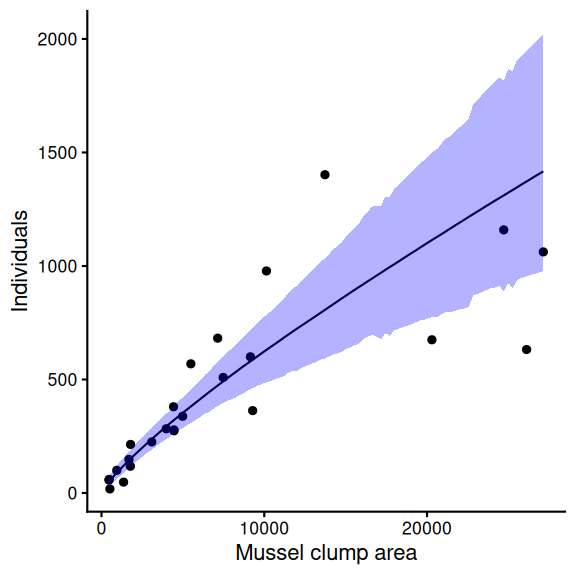

```r
ggplot(newdata, aes(y=prob, x=AREA)) +
    geom_point(data=peake, aes(y=INDIV)) +
    geom_line() +
    geom_ribbon(aes(ymin=lower.HPD, ymax=upper.HPD), fill='blue', alpha=0.3) +
    scale_y_continuous('Individuals') +
    scale_x_continuous('Mussel clump area') +
    theme_classic()
```

```r
## spaghetti plot
newdata = emmeans(peake_rstanarm4, ~AREA, at=peake_grid) |>
    regrid() |>
    gather_emmeans_draws()
newdata |> head()
```

```
# A tibble: 6 × 5
# Groups:   AREA [1]
   AREA .chain .iteration .draw .value
  <dbl>  <int>      <int> <int>  <dbl>
1  462.     NA         NA     1   53.3
2  462.     NA         NA     2   47.9
3  462.     NA         NA     3   73.3
4  462.     NA         NA     4   52.4
5  462.     NA         NA     5   42.0
6  462.     NA         NA     6   61.6
```

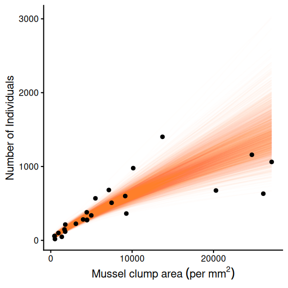

```r
ggplot(newdata,  aes(y=.value,  x=AREA)) +
    geom_line(aes(group=.draw), colour = 'orange', alpha=0.01) +
    geom_point(data=peake,  aes(y=INDIV)) +
    scale_y_continuous('Number of Individuals') +
    scale_x_continuous(expression(Mussel~clump~area~(per~mm^2))) +
    theme_classic()
```

**brms**

```r
## Using emmeans
peake_grid = with(peake, list(AREA = seq(min(AREA), max(AREA), len=100)))

newdata = emmeans(peake_brm4, ~AREA, at=peake_grid, type='response') |> as.data.frame()
head(newdata)
```

```
      AREA      prob lower.HPD upper.HPD
  462.2500  49.71861  34.03015  69.22098
  731.7629  72.56104  52.69535  96.42318
 1001.2759  93.80745  70.85903 120.69035
 1270.7888 114.05134  88.25413 143.45276
 1540.3017 133.63179 108.05662 167.96119
 1809.8146 152.67787 125.28604 189.07590

Point estimate displayed: median
Results are back-transformed from the log scale
HPD interval probability: 0.95
```

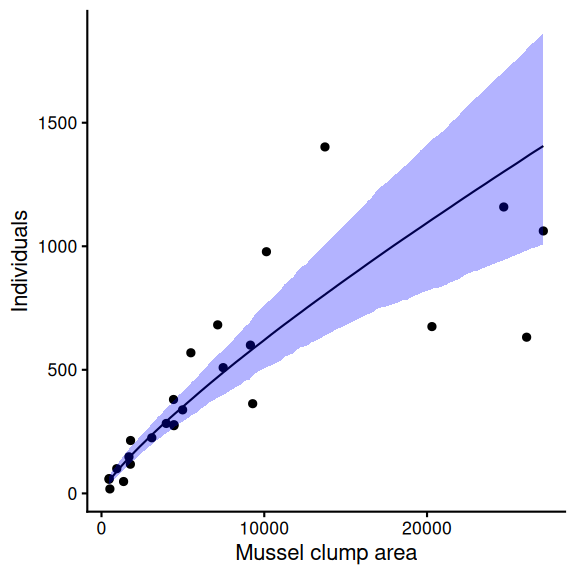

```r
ggplot(newdata, aes(y=prob, x=AREA)) +
    geom_point(data=peake, aes(y=INDIV)) +
    geom_line() +
    geom_ribbon(aes(ymin=lower.HPD, ymax=upper.HPD), fill='blue', alpha=0.3) +
    scale_y_continuous('Individuals') +
    scale_x_continuous('Mussel clump area') +
    theme_classic()
```

```r
## spaghetti plot
newdata = emmeans(peake_brm4, ~AREA, at=peake_grid) |>
    regrid() |>
    gather_emmeans_draws()
newdata |> head()
```

```
# A tibble: 6 × 5
# Groups:   AREA [1]
   AREA .chain .iteration .draw .value
  <dbl>  <int>      <int> <int>  <dbl>
1  462.     NA         NA     1   47.3
2  462.     NA         NA     2   80.1
3  462.     NA         NA     3   43.3
4  462.     NA         NA     4   43.8
5  462.     NA         NA     5   63.4
6  462.     NA         NA     6   55.2
```

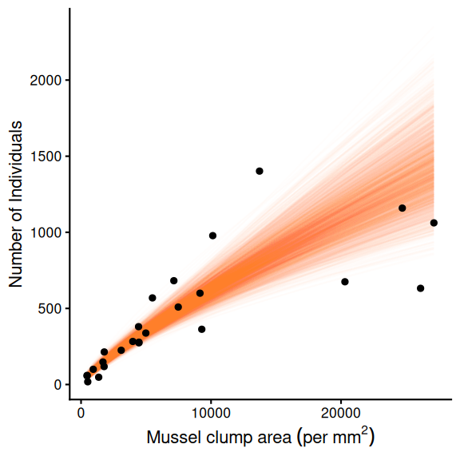

```r
ggplot(newdata,  aes(y=.value,  x=AREA)) +
    geom_line(aes(group=.draw), colour = 'orange', alpha=0.01) +
    geom_point(data=peake,  aes(y=INDIV)) +
    scale_y_continuous('Number of Individuals') +
    scale_x_continuous(expression(Mussel~clump~area~(per~mm^2))) +
    theme_classic()
```

## 13 References

Peake, A. J., and G. P. Quinn. 1993. “Temporal Variation in Species-Area Curves for Invertebrates in Clumps of an Intertidal Mussel.” *Ecography* 16: 269–77.